# Gabitto split into two donor-disjoint halves, twice: the donor-level regression `donor_wls` replicates best, `state_adjusted` has the lowest replicate score and no signal that replicates, and a fifth 

# 4 All rules side by side

| method | score, split1 | score, split2 | score_cross, split1 | score_cross, split2 | z_rms, split1 | z_rms, split2 | corr_all, split1 | corr_all, split2 | corr_nominated, split1 | corr_nominated, split2 | sign_rep, split1 | sign_rep, split2 |
| --- | --- | --- | --- | --- | --- | --- | --- | --- | --- | --- | --- | --- |
| `stored` | 0.47 | 0.49 | 0.27 | 0.28 | 0.38 | 0.43 | 0.40 | 0.37 | 0.51 | 0.46 | 0.81 | 0.66 |
| `null_rescaled` | -0.06 | 0.09 | -0.14 | -0.13 | 1.09 | 1.18 | 0.40 | 0.39 | 0.52 | 0.47 | 0.80 | 0.66 |
| `deshrunk` | 0.61 | 0.61 | 0.39 | 0.36 | 0.38 | 0.36 | 0.40 | 0.37 | 0.51 | 0.46 | 0.81 | 0.66 |
| `raw` | -0.16 | -0.19 | -0.14 | -0.18 | 1.03 | 1.00 | 0.43 | 0.37 | 0.61 | 0.51 | 0.81 | 0.67 |
| `raw@esvd_nofloor` | -0.22 | -0.21 | -0.15 | -0.18 | 0.98 | 1.00 | 0.40 | 0.33 | 0.54 | 0.44 | 0.80 | 0.66 |
| `raw@total` | -0.20 | -0.21 | -0.16 | -0.20 | 0.93 | 0.92 | 0.39 | 0.39 | 0.59 | 0.54 | 0.84 | 0.71 |
| `raw_null` | -0.15 | -0.12 | -0.14 | -0.15 | 0.78 | 0.74 | 0.44 | 0.39 | 0.61 | 0.53 | 0.80 | 0.69 |
| `raw_null@esvd_nofloor` | -0.17 | -0.14 | -0.15 | -0.17 | 0.78 | 0.74 | 0.41 | 0.36 | 0.55 | 0.47 | 0.80 | 0.68 |
| `raw_null@total` | -0.14 | -0.13 | -0.14 | -0.18 | 0.74 | 0.72 | 0.40 | 0.40 | 0.61 | 0.56 | 0.83 | 0.75 |
| `donor_wls` | -0.17 | -0.26 | -0.16 | -0.23 | 0.94 | 0.85 | 0.38 | 0.50 | 0.55 | 0.64 | 0.80 | 0.73 |
| `donor_wls@esvd_nofloor` | -0.22 | -0.26 | -0.17 | -0.24 | 0.89 | 0.85 | 0.39 | 0.49 | 0.54 | 0.63 | 0.80 | 0.72 |
| `donor_wls@esvd_depth` | -0.21 | -0.26 | -0.17 | -0.23 | 0.89 | 0.86 | 0.39 | 0.49 | 0.54 | 0.63 | 0.80 | 0.72 |
| `donor_wls@total` | -0.16 | -0.25 | -0.15 | -0.24 | 0.94 | 0.85 | 0.43 | 0.53 | 0.56 | 0.64 | 0.84 | 0.72 |
| `donor_wls@sf` | -0.16 | -0.25 | -0.15 | -0.24 | 0.94 | 0.85 | 0.42 | 0.53 | 0.56 | 0.64 | 0.84 | 0.72 |
| `donor_wls@tmm` | -0.16 | -0.25 | -0.15 | -0.24 | 0.94 | 0.85 | 0.42 | 0.53 | 0.56 | 0.64 | 0.84 | 0.71 |
| `gap_trend` | -0.14 | -0.20 | -0.16 | -0.21 | 0.93 | 0.89 | 0.39 | 0.52 | 0.52 | 0.65 | 0.80 | 0.72 |
| `gap_trend@esvd_nofloor` | -0.19 | -0.22 | -0.17 | -0.22 | 0.89 | 0.88 | 0.40 | 0.52 | 0.49 | 0.63 | 0.81 | 0.71 |
| `gap_trend@total` | -0.13 | -0.22 | -0.14 | -0.22 | 0.94 | 0.87 | 0.42 | 0.55 | 0.52 | 0.65 | 0.83 | 0.71 |
| `embed_prior` | -0.17 | -0.26 | -0.16 | -0.23 | 0.93 | 0.85 | 0.38 | 0.50 | 0.55 | 0.64 | 0.80 | 0.72 |
| `embed_prior@esvd_nofloor` | -0.22 | -0.27 | -0.18 | -0.24 | 0.88 | 0.84 | 0.39 | 0.49 | 0.54 | 0.63 | 0.81 | 0.72 |
| `embed_prior@total` | -0.15 | -0.25 | -0.15 | -0.23 | 0.94 | 0.85 | 0.43 | 0.53 | 0.56 | 0.64 | 0.84 | 0.72 |
| `state_adjusted` | -0.58 | -0.65 | -0.06 | -0.13 | 1.05 | 1.00 | 0.00 | 0.00 | -0.03 | 0.05 | 0.50 | 0.53 |
| `state_adjusted@esvd_nofloor` | -0.62 | -0.66 | -0.07 | -0.13 | 1.05 | 1.00 | 0.00 | -0.02 | -0.08 | 0.01 | 0.49 | 0.52 |
| `state_adjusted@total` | -0.60 | -0.65 | -0.07 | -0.13 | 1.04 | 0.99 | -0.01 | -0.02 | -0.10 | 0.01 | 0.51 | 0.51 |
| `deseq2` | -0.14 | -0.22 | -0.14 | -0.22 | 0.97 | 0.89 | 0.37 | 0.35 | 0.47 | 0.54 | 0.82 | 0.69 |

Table 3. Every method in the two splits. `score`, `z_rms` and `corr_all` are over all 5256 genes; `corr_nominated` and `sign_rep` are over the genes eSVD-DE’s test nominates in at least one half (397 and 389 genes).

## 4.1 The replicate score alone ranks `state_adjusted` first, and its logFC do not replicate

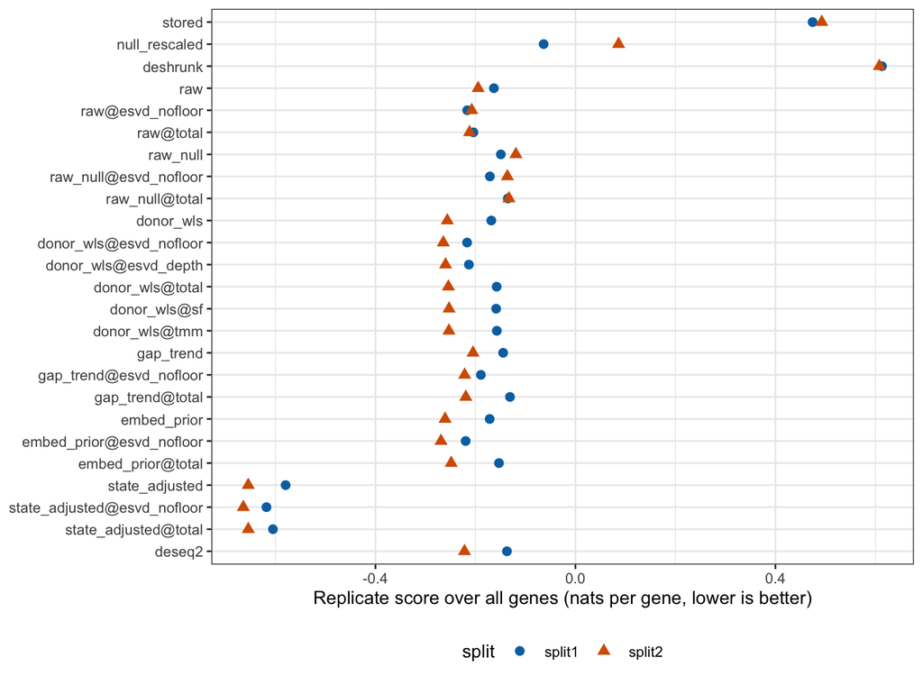

Figure 1. The replicate score of every method over all genes, one point per split.

The three `state_adjusted` variants score -0.64 to -0.62 nats per gene on average over the two splits, and the best of the other methods scores -0.24. The same rule’s two halves correlate at 0.00 and 0.00 over all genes and at -0.03 and 0.05 over the genes eSVD-DE’s test nominates, and the sign of a nominated gene holds in the other half 50% and 53% of the time, which is the rate of a coin. Its own Wald test nominates 13 and 4 genes, none of them in both halves.

The score is low because the rule’s logFC are small and its SE says so. The SD of its logFC across genes is 0.13 and 0.12 against 0.26 and 0.25 for `donor_wls`, the root mean square difference between the halves is 0.18 and 0.17 against 0.29 and 0.25, and its `z_rms` is 1.05 and 1.00. A pair of estimates that are noise around zero with an honest SE satisfies the model behind the replicate score exactly, and a truth-free score cannot separate that from an accurate estimate of a small effect. The score against the other half’s DESeq2 does separate them: there `state_adjusted` scores -0.06 and -0.13 against -0.16 and -0.23 for `donor_wls`, because its logFC do not predict an independent estimate of the marginal effect (correlation 0.02 and 0.01 against 0.38 and 0.43).

The rule subtracts from each gene’s arm coefficient its component along the fitted loadings, and the fit here has rank 30 with 40 donors per half. An embedding of that rank can carry most donor-level contrasts, the arm contrast among them, so the subtraction removes the effect together with the cell-state shift. The second loop’s bank was fitted at rank 5, and its report listed the rank as untested (open item 0C of `CLAUDE_kevin.md`). The target of `state_adjusted` is the effect at fixed cell state, which may be smaller than the marginal effect; a real effect at fixed cell state would still have the same sign in two halves, and the rule’s logFC show no such agreement.

On a real cohort the replicate score has to be read with the correlation between the halves beside it. `state_adjusted` wins the score by reporting logFC with half the spread of every other rule and no agreement between halves, so at rank 30 and 40 donors it has removed the case-control signal and is not usable. It is left out of the rankings below.

## 4.2 Among the rules that keep a signal, the `donor_wls` family scores best

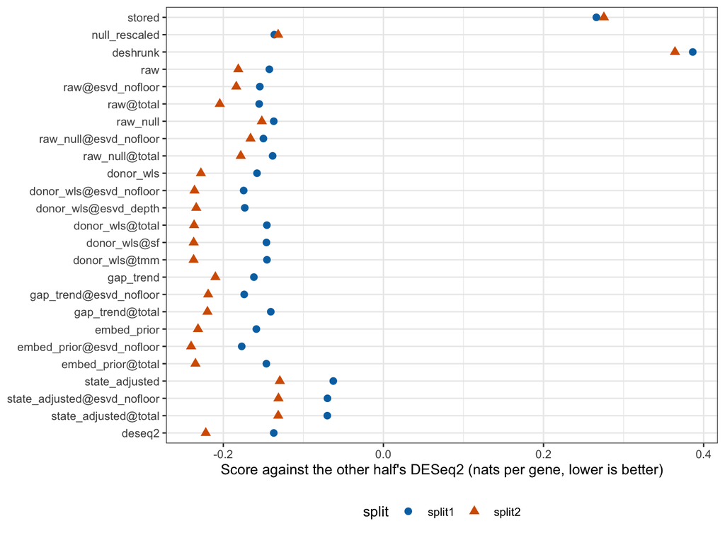

Figure 2. Each method’s pair from one half scored against the other half’s pseudobulk DESeq2 estimate, averaged over the two directions; one point per split.

Without `state_adjusted`, the lowest mean replicate score belongs to `embed_prior@esvd_nofloor`, `donor_wls@esvd_nofloor`, `donor_wls@esvd_depth`, in that order, and the lowest mean score against the other half’s DESeq2 to `embed_prior@esvd_nofloor`, `donor_wls@esvd_nofloor`, `donor_wls@esvd_depth`. `embed_prior` and `donor_wls` report the same logFC and differ by under 0.01 nats in either score, as on the simulated banks. `donor_wls@esvd_nofloor` scores -0.22 and -0.26 in the two splits, `deseq2` -0.14 and -0.22, `raw` -0.16 and -0.19, `null_rescaled` -0.06 and 0.09 and `stored` 0.47 and 0.49. The ranking of `donor_wls` over `deseq2` and of both over `stored` is the ranking of the three simulated banks.

**The library.** Removing the posterior’s floor from the fitted library improves `donor_wls` by 0.05 and 0.01 nats in the two splits, with the gain in the genes with 80% zeros or more (Table 4). With the cell’s summed counts as the library the score is -0.16 and -0.25, behind the unfloored fitted library in split 1 and equal to it in split 2, and the correlation between the halves is slightly higher (0.43 and 0.53 against 0.39 and 0.49). Every covariate of this design is constant within a donor, the setting in which the beyond-score study found the fitted library and the summed counts equivalent. `@esvd_depth` equals `@esvd_nofloor` to 0.005 nats, so the fitted library’s covariate columns add nothing here either.

Table 4. The replicate score by gene stratum, mean of the two splits. Genes per stratum in split 1: under 80% zeros 2912; 80 to 95% zeros 1986; over 95% zeros 358; rate estimated 4266; rate at the cap 990.

| method | under 80% zeros | 80 to 95% zeros | over 95% zeros | rate estimated | rate at the cap |
| --- | --- | --- | --- | --- | --- |
| `stored` | 0.19 | 0.73 | 1.49 | 0.48 | 0.48 |
| `null_rescaled` | -0.15 | 0.09 | 0.91 | -0.07 | 0.37 |
| `raw` | -0.44 | 0.02 | 0.87 | -0.25 | 0.13 |
| `donor_wls` | -0.45 | -0.02 | 0.70 | -0.28 | 0.08 |
| `donor_wls@esvd_nofloor` | -0.46 | -0.08 | 0.65 | -0.30 | 0.03 |
| `donor_wls@total` | -0.42 | -0.06 | 0.68 | -0.26 | 0.04 |
| `deseq2` | -0.41 | -0.04 | 0.88 | -0.25 | 0.12 |

The order of the simulated banks holds on Gabitto: `donor_wls` ahead of pseudobulk DESeq2, both far ahead of `stored`, and the unfloored fitted library at least as good as the floored one. The fitted library is not better than summed counts on this cohort, whose covariates are all donor-level.

## 4.3 Correlation over the nominated genes

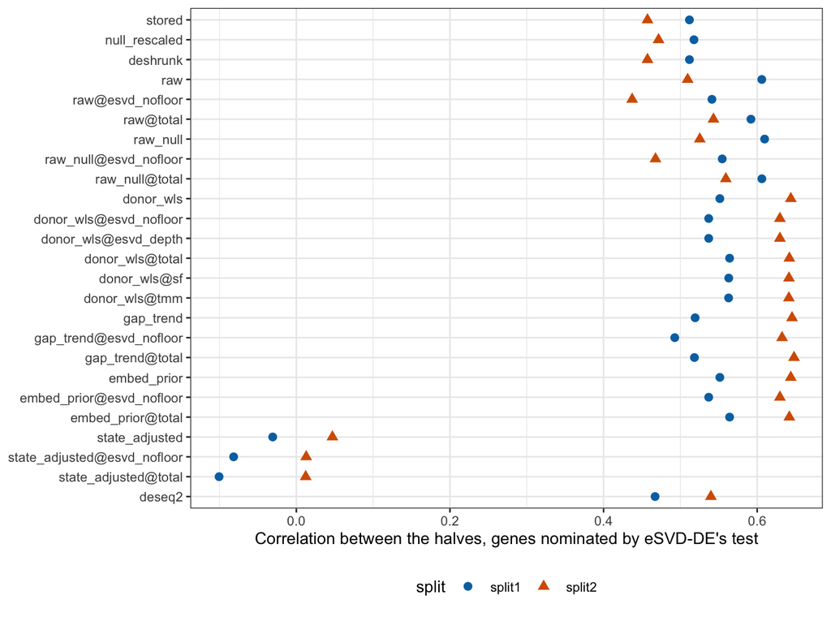

Figure 3. Correlation of the two halves’ logFC over the genes that eSVD-DE’s test nominates in at least one half (the same genes for every method); one point per split.

| method | half 1, split1 | half 1, split2 | half 2, split1 | half 2, split2 | both, split1 | both, split2 | sign_rep, split1 | sign_rep, split2 | slope_rep, split1 | slope_rep, split2 |
| --- | --- | --- | --- | --- | --- | --- | --- | --- | --- | --- |
| `null_rescaled` | 227 | 196 | 275 | 325 | 68 | 70 | 0.78 | 0.68 | 0.44 | 0.33 |
| `raw` | 95 | 22 | 133 | 133 | 11 | 3 | 0.84 | 0.86 | 0.42 | 0.39 |
| `raw_null` | 2 | 3 | 5 | 0 | 0 | 0 | 0.86 | NA | 0.50 | NA |
| `donor_wls` | 6 | 2 | 15 | 0 | 0 | 0 | 0.90 | NA | 0.32 | NA |
| `donor_wls@esvd_nofloor` | 0 | 1 | 4 | 0 | 0 | 0 | NA | NA | NA | NA |
| `donor_wls@total` | 10 | 2 | 17 | 1 | 0 | 0 | 0.89 | NA | 0.36 | NA |
| `gap_trend` | 10 | 7 | 54 | 28 | 4 | 3 | 0.83 | 0.97 | 0.41 | 0.57 |
| `embed_prior` | 4 | 0 | 0 | 0 | 0 | 0 | NA | NA | NA | NA |
| `deseq2` | 6 | 4 | 29 | 7 | 0 | 1 | 0.74 | 1.00 | 0.21 | 0.58 |

Table 5. Each rule’s own nominations (BH 5% on its Wald test): genes nominated per half and in both, the share of discoveries with the same sign in the other half, and the replication slope. A blank is fewer than five discoveries.

On the genes nominated by eSVD-DE’s test, `donor_wls` and its variants replicate better than the posterior-based `stored` and better than DESeq2 in both splits. `raw` is first in one split and behind both `donor_wls` and DESeq2 in the other.

## 4.4 The SE against the disagreement between the halves

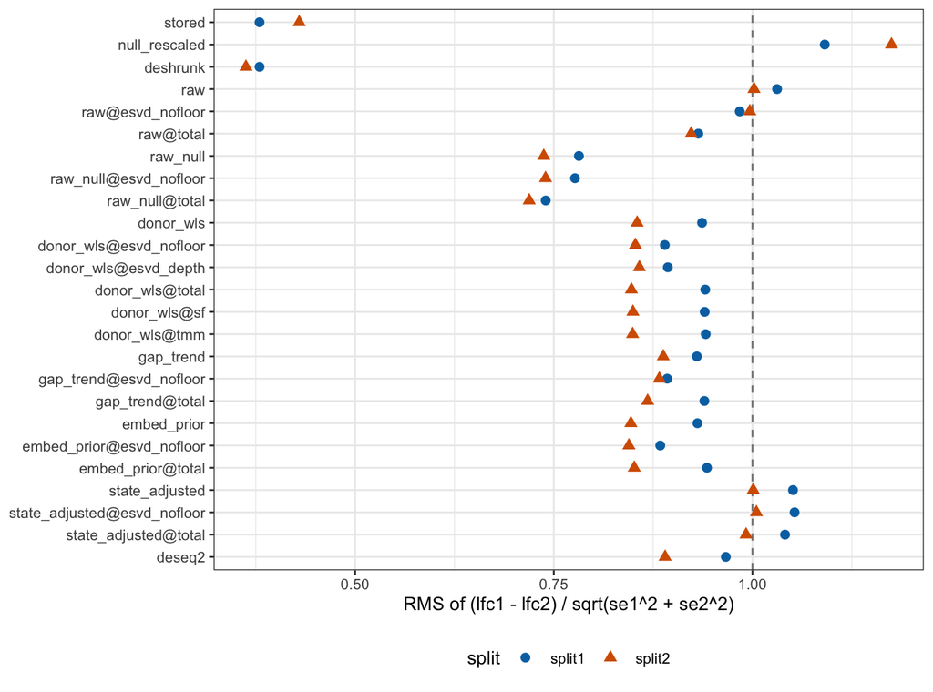

Figure 4. Root mean square of the standardized difference between the halves; 1 (dashed) means the SEs explain the disagreement, below 1 that they are too large.

The `stored` SE gives a `z_rms` of 0.38 and 0.43, so it is 2.6 and 2.3 times the SE that would explain the disagreement between the halves, the same direction as the 3.4 to 5 measured against simulated replicate cohorts in the SE exploration and a smaller factor. `deshrunk` is as wide (0.38 and 0.36). `null_rescaled` is at 1.09 and 1.18 over all genes and at 1.30 and 1.60 for the genes at the nuisance cap, where its SE is too small. `raw` is at 1.03 and 1.00 and `deseq2` at 0.97 and 0.89. `donor_wls@esvd_nofloor` is at 0.89 and 0.85, an SE about 10 to 15% larger than the disagreement requires. A shared true effect that differs between the halves’ donors would push `z_rms` above 1, so a value below 1 is an SE that is too large and not an artifact of the split.

The stored SE is about 2.5 times too large on real data as well, and no rescaling by the empirical null repairs it for the capped genes. `donor_wls` errs on the conservative side by roughly a tenth.

## 4.5 Does a nominated gene keep its sign in the other half?

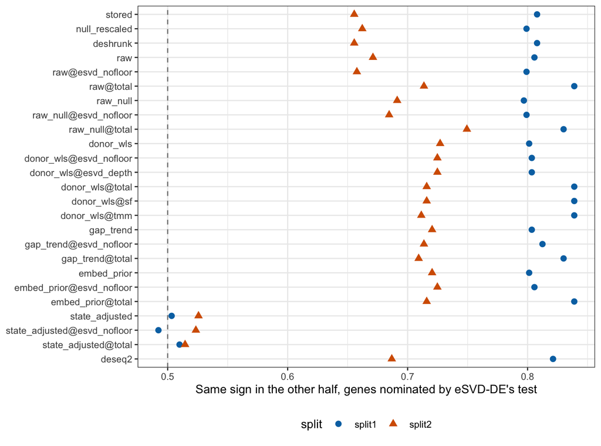

Figure 5. Share of the genes called by eSVD-DE’s test in one half whose logFC, under each method, has the same sign in the other half; one point per split.

Table 6. The genes eSVD-DE’s test calls at 5% FDR in one half, by group. `sign_rep` uses the `stored` logFC of the two halves and `sign_rep_wls` that of `donor_wls@esvd_nofloor`; `slope_rep` is the replication slope of the `stored` logFC; the `donor_wls` p-value is the nominal Wald p of `donor_wls@esvd_nofloor` in the discovering half.

| split | group | num_calls | sign_rep | sign_rep_wls | slope_rep | median_abs_lfc |
| --- | --- | --- | --- | --- | --- | --- |
| split1 | all calls | 453 | 0.81 | 0.80 | 0.44 | 0.45 |
| split1 | rate estimated | 353 | 0.82 | 0.84 | 0.44 | 0.42 |
| split1 | rate at the cap | 100 | 0.76 | 0.69 | 0.46 | 0.58 |
| split1 | donor_wls p < 0.05 | 275 | 0.82 | 0.82 | 0.49 | 0.51 |
| split1 | donor_wls p >= 0.05 | 178 | 0.79 | 0.78 | 0.35 | 0.36 |
| split1 | donor_wls p < 0.01 | 120 | 0.86 | 0.87 | 0.47 | 0.59 |
| split2 | all calls | 447 | 0.66 | 0.72 | 0.32 | 0.44 |
| split2 | rate estimated | 300 | 0.76 | 0.80 | 0.38 | 0.41 |
| split2 | rate at the cap | 147 | 0.45 | 0.57 | 0.15 | 0.46 |
| split2 | donor_wls p < 0.05 | 253 | 0.79 | 0.89 | 0.37 | 0.50 |
| split2 | donor_wls p >= 0.05 | 194 | 0.48 | 0.52 | 0.21 | 0.39 |
| split2 | donor_wls p < 0.01 | 109 | 0.83 | 0.92 | 0.43 | 0.59 |

Of the genes eSVD-DE’s test calls in one half, 81% and 66% have a `stored` logFC of the same sign in the other half (Table 6), and every rule that keeps a signal is between 66% and 84% (Figure 5). The rule that supplies the logFC therefore matters little for the sign, and the calls matter more. A call whose gene has its nuisance rate at the cap keeps its sign 76% and 45% of the time against 82% and 76% for the other calls. A call that `donor_wls@esvd_nofloor` supports at nominal $p < 0.05$ in the discovering half keeps its sign 82% and 79% of the time (82% and 89% under the rule’s own logFC) against 79% and 48% for the unsupported calls, and at $p < 0.01$ the share is 87% and 92% under the rule’s logFC. The replication slope of the calls is 0.44 and 0.32: a called gene’s logFC reappears in the other half at a third to a half of its size, the winner’s curse that Writeup49 measured between cohorts.

A sign that flips is not by itself a false discovery, since a small true effect estimated from 40 donors can change sign by chance. The share is still informative as a bound: a null gene keeps its sign half the time, so a sign agreement of $a$ among the calls allows at most $2(1 - a)$ of them to be null, which is 38% and 69% here against a nominal 5%. The beyond-score study measured a false discovery proportion of 18 to 19% for the package’s test on the two harder simulated banks.

The expectation that a nominated gene keeps its sign in the other half holds for about four calls in five in one split and two in three in the other, under any rule’s logFC. In the second split the failures are concentrated in the calls at the nuisance cap and the calls without support from `donor_wls` in the discovering half, both of which keep their sign about half the time; in the first split the differences have the same direction and are small. A call with `donor_wls` $p < 0.01$ keeps its sign about nine times in ten in both.

# 5 Recommendation

**Which rule.** By the replicate score and the score against an independent DESeq2 estimate, the `donor_wls` family is first among the rules that retain a signal; by the correlation over nominated genes it is in the leading group in both splits; its SE is within 15% of the disagreement between the halves, on the conservative side. This is a consequence of the evidence above and agrees with the three simulated banks. Between the libraries, `@esvd_nofloor` is at least as good as the floored library in both splits and is kept; summed counts would serve equally on a cohort with donor-level covariates only, and the choice of the fitted library rests on the simulated cell-level confounders, which this cohort does not test.

**Which rule not.** `state_adjusted` is not usable at `k = 30` on 40 donors, and the replicate score must not be used alone to choose a rule (a consequence). `stored` should not be the reported SE (a consequence, third time measured). `raw` is a reasonable second, with an SE near 1 and a less stable correlation across the two splits.

**How to read an eSVD-DE call.** Reporting, beside each call, whether the `donor_wls@esvd_nofloor` interval excludes zero and whether the gene’s nuisance rate is at the cap identifies the calls that fail to keep their sign (a choice, supported by Table 6 on two splits of one cohort).

1. Fit the cohort with `eSVD2::eSVD_helper()` as now.
2. Rebuild the counts and the covariates of the fit and form the fitted library without the posterior’s floor, the exponential of the fit’s linear predictor over every covariate but the arm.
3. Report the log2 fold change and its SE from `donor_wls@esvd_nofloor`.
4. Beside each gene called by the package’s test, report the Wald p-value of that pair and the nuisance status of the gene; treat a call with Wald $p \geq 0.05$ or a capped rate as provisional.
5. Check on a split of the cohort’s donors, as here, that the rule’s two halves correlate over the nominated genes. A rule whose halves do not correlate has no signal at this rank and donor count, whatever its score. If `state_adjusted` is wanted for the effect at fixed cell state, run this check first and lower the rank until it passes.

# 6 What we glossed over

- **Two splits of one cohort.** The two splits share all 80 donors, and 46 donors have the same half label in both, so the splits are two looks at one data set and their agreement is not independent confirmation. Several orders differ between the splits (`raw` against `donor_wls` in section 4.3), and differences of under 0.02 nats or 0.05 in a correlation are within that variation. More splits would cost 40 minutes of fitting each.
- **Shared bias is invisible to a split.** A bias common to both halves (the depth adjustment, the half count for sparse genes, confounding by an unmeasured donor covariate) cancels in the difference and raises the correlation. The simulated banks, which have a truth, are the evidence against such a bias for `donor_wls`; the cross score against DESeq2 is a partial check here.
- **The rules’ own tests use a normal reference.** `donor_wls` moderates its variance and has a $t$ reference with finite degrees of freedom, which would nominate slightly fewer genes still.
- **Each half has half the cohort’s power.** The counts of nominated genes and the sign agreement describe cohorts of 40 donors, not the cohort of 80.
- **Assay is not adjusted for**, as in Writeup45 (two assays, `10x3v3` and `10xmultiome`), and neither split stratified on it, on PMI or on age at death (Table 1 shows the realized means).
- **The fits stopped after about 15 iterations per phase** at the default tolerance, which is why each took about 37 minutes against the 4 hours of the full cohort on the server. The loss decreased monotonically and no line-search warning was raised.
- **Why `state_adjusted` loses the signal was not dissected.** The rank explanation in section 4.1 is the mechanism the rule’s construction suggests; a refit at a lower rank would test it.
- **The package’s p-value was not recomputed.** Whether the test should follow the reported pair is open item 00A of `CLAUDE_kevin.md`.

# 7 Files

All paths are relative to `additional_context/2026-11-15_gabitto/` unless they start with `OUT`, which is `out/2026-11-15_gabitto/` beside the repository clone (not in git).

| File | What it is |
| --- | --- |
| `paths_claude.R` | the data file, the output folder and the design shared by every step |
| `01_split-donors_claude.R` | the two stratified splits; writes `csv/split_donors.csv` (one row per donor), `csv/split_balance.csv` and `OUT/gabitto_splits.RData` |
| `02_fit-esvd_claude.R <label>` | one eSVD-DE fit; writes `OUT/gabitto_<label>_esvd.RData` (the diet `eSVD` object) |
| `03_apply-rules_claude.R <label>` | every rule, variant and DESeq2 on one fitted half; writes `OUT/gabitto_<label>_rules.RData` (genes x methods matrices of logFC and SE) |
| `04_evaluate_claude.R` | the comparisons; writes `OUT/gabitto_evaluation.RData`, `OUT/figures/*.png` and the tables below |
| `helpers_claude.R` | the replication statistics and the two figure functions, shared by step 4 and this document |
| `csv/fits.csv` | one row per fit |
| `csv/agreement.csv` | one row per split, method and gene set: score, `z_rms`, coverage, correlations, sign agreement |
| `csv/discovery.csv` | one row per split, method and nomination: discoveries per half, `sign_rep`, `slope_rep`, share replicated at nominal p < 0.05 |
| `csv/cross_score.csv` | one row per split and method: the score against the other half’s DESeq2 |
| `csv/esvd_calls.csv` | one row per split and group of eSVD-DE’s calls: number of calls, sign agreement, replication slope |
| `csv/summary.csv` | one row per split and method, the columns of the three tables above side by side |
| `csv/rule_runs.csv` | one row per fit and method: error message (empty when the rule ran) and seconds |
| `csv/gene_pairs.csv.gz` | one row per split, method and gene: the two halves’ logFC and SE and the nominations; the figures of section 3 are drawn from it |
| `run_after-fits_claude.sh` | waits for the four fits, then runs step 3 on each and step 4 |
| `output/` | the logs of the four fits and of steps 3 and 4 |

# 8 References

- Gabitto et al. (2024), *Integrated multimodal cell atlas of Alzheimer’s disease*, Nature Neuroscience, doi:10.1038/s41593-024-01774-5 (the cohort). *Verify before citing.*
- Lin, Qiu and Roeder (2024), *eSVD-DE*, BMC Bioinformatics 25:113, doi:10.1186/s12859-024-05724-7.
- Love, Huber and Anders (2014), DESeq2, Genome Biology 15:550, doi:10.1186/s13059-014-0550-8.
- `additional_context/2026-11-12_autoresearch_beyond-score_claude.Rmd` (the rules on the three simulated banks).
- `autoresearch_lfcse/notes/RUN_nov11_claude.md`, `autoresearch_lfcse2/notes/RUN_nov11_claude.md` (the two loops).
- `WAS2CODE_ANALYSIS_REPO`, `code/tati/Writeup45_gabitto_final-de/` (the design) and `code/kevin/Writeup49_fig4-pseudobulk/` (the split-half and replication-slope conventions).